# Chapter 4: Mixed-Effect Models for Time Series within Factorial Designs

Keith Lohse, PhD, PStat

2026-07-30

In rehabilitation, for instance we might be interested in the rate at which a person with Parkinson’s disease acquires a skill when they are on or off dopamine replacement medication. Alternately, might be interested in hemibody differences between the left and right arms, or left and right legs, over time.

As before however, we will work with our hypothetical dataset in which younger and older adults walked in a virtual environment on four different trials under three different conditions (arbitrary conditions A, B, and C).

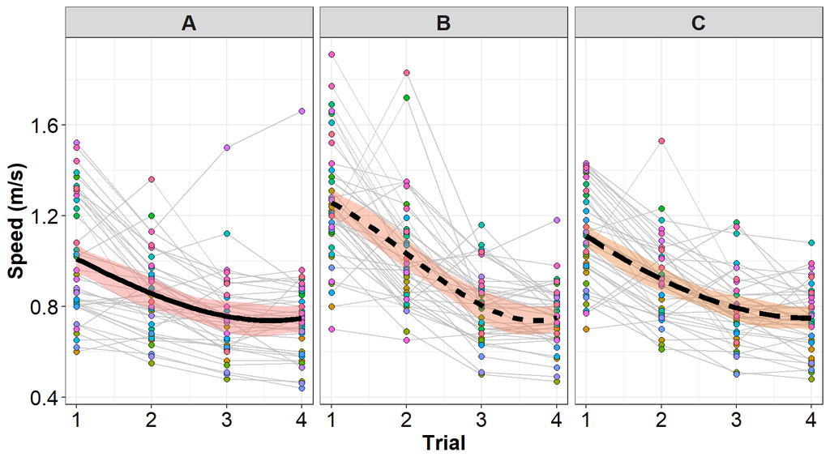